# ANSWERS: Working with untidy and tidy data

Data Science for Biologists, Spring 2020

Madeline Greene

# Questions

#### Preface Question

Look at the YAML front matter: there is something NEW! Read about params [here](https://rmarkdown.rstudio.com/lesson-6.html). In this case we set a global parameter for the RMarkdown file that corresponds to the path where data lives! We can proceed to use this as a variable like so (always `params$`, like a column in a data frame!). Use this variable for your paths, e.g. `read_csv(paste0(params$data_path, <NAMEOFFILE>))`

```r
params$data_path
```

```
## [1] "data/"
```

#### Question 1

```r
# Code chunk to read in and examine the data with head()
read_csv(paste0(params$data_path, "mcv_immunized_percent_of_one_year_olds.csv")) -> mcv_immunized #other way is to rename the name of the file
head(mcv_immunized) #just viewing head
```

```
## # A tibble: 6 x 33
##   country `1980` `1981` `1982` `1983` `1984` `1985` `1986` `1987` `1988` `1989`
##   <chr>    <dbl>  <dbl>  <dbl>  <dbl>  <dbl>  <dbl>  <dbl>  <dbl>  <dbl>  <dbl>
## 1 Afghan…     11     NA      8      9     14     14     14     31     34     22
## 2 Albania     90     90     93     96     96     96     96     96     96     96
## 3 Algeria     NA     NA     NA     NA     NA     68     67     73     81     82
## 4 Andorra     NA     NA     NA     NA     NA     NA     NA     NA     NA     NA
## 5 Angola      NA     NA     NA     26     35     44     44     55     56     48
## 6 Antigu…     NA     NA     NA     48     73     69     80     89     95     95
## # … with 22 more variables: `1990` <dbl>, `1991` <dbl>, `1992` <dbl>,
## #   `1993` <dbl>, `1994` <dbl>, `1995` <dbl>, `1996` <dbl>, `1997` <dbl>,
## #   `1998` <dbl>, `1999` <dbl>, `2000` <dbl>, `2001` <dbl>, `2002` <dbl>,
## #   `2003` <dbl>, `2004` <dbl>, `2005` <dbl>, `2006` <dbl>, `2007` <dbl>,
## #   `2008` <dbl>, `2009` <dbl>, `2010` <dbl>, `2011` <dbl>
```

```r
# Code chunk to convert data to tidy
mcv_immunized %>%
  pivot_longer(`1980`:`2011`, names_to = "year", values_to = "percent") -> tidymcv

tidymcv
```

```
## # A tibble: 6,176 x 3
##    country     year  percent
##    <chr>       <chr>   <dbl>
##  1 Afghanistan 1980       11
##  2 Afghanistan 1981       NA
##  3 Afghanistan 1982        8
##  4 Afghanistan 1983        9
##  5 Afghanistan 1984       14
##  6 Afghanistan 1985       14
##  7 Afghanistan 1986       14
##  8 Afghanistan 1987       31
##  9 Afghanistan 1988       34
## 10 Afghanistan 1989       22
## # … with 6,166 more rows
```

#### Question 2

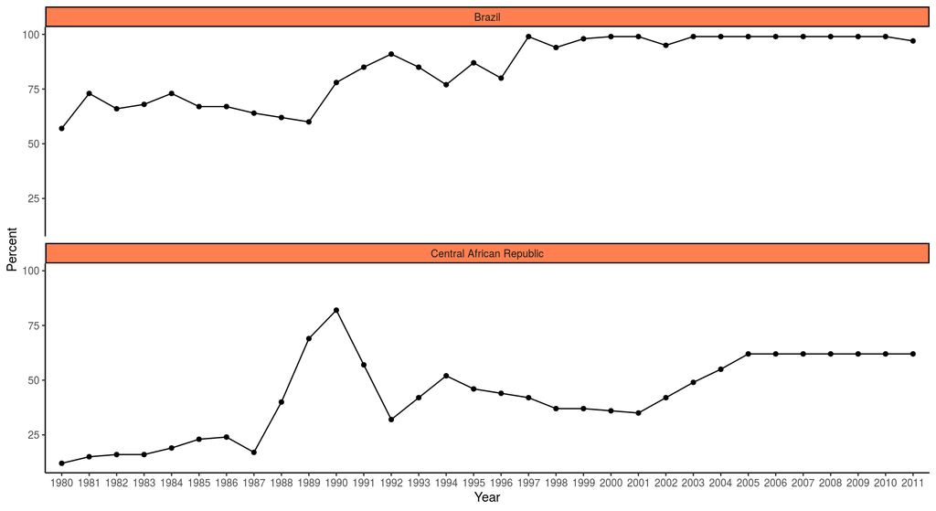

```r
# Code chunk to plot the data
tidymcv %>%
  filter(country %in% c("Brazil","Central African Republic")) %>%
  #comparing these two countries
  ggplot(aes(x =year, y = percent, group = country)) +
  geom_line() +
  geom_point() +
  facet_wrap(~country, nrow=2)+
  #nrow = overtop of eachother
  theme(strip.background = element_rect(fill = "coral")) +
  labs(x = "Year", y = "Percent")
```

#### Question 3

```r
# Code chunk to read in and examine the data with head()
read_csv(paste0(params$data_path, "dtp3_immunized_percent_of_one_year_olds.csv")) -> dtp3_immunized
dtp3_immunized
```

```
## # A tibble: 193 x 33
##    country `1980` `1981` `1982` `1983` `1984` `1985` `1986` `1987` `1988` `1989`
##    <chr>    <dbl>  <dbl>  <dbl>  <dbl>  <dbl>  <dbl>  <dbl>  <dbl>  <dbl>  <dbl>
##  1 Afghan…      4      3      5      5     16     15     11     25     35     33
##  2 Albania     94     94     95     95     95     96     96     96     96     94
##  3 Algeria     NA     NA     NA     NA     NA     69     73     79     85     87
##  4 Andorra     NA     NA     NA     NA     NA     NA     NA     NA     NA     NA
##  5 Angola      NA     NA     NA      6      8      8     10     10     12     18
##  6 Antigu…     54     79     79     99     94     99     96     97     98     99
##  7 Argent…     44     49     58     61     62     66     67     75     80     80
##  8 Armenia     NA     NA     NA     NA     NA     NA     NA     NA     NA     NA
##  9 Austra…     33     40     48     55     62     68     75     81     88     93
## 10 Austria     90     90     90     90     90     90     90     90     90     90
## # … with 183 more rows, and 22 more variables: `1990` <dbl>, `1991` <dbl>,
## #   `1992` <dbl>, `1993` <dbl>, `1994` <dbl>, `1995` <dbl>, `1996` <dbl>,
## #   `1997` <dbl>, `1998` <dbl>, `1999` <dbl>, `2000` <dbl>, `2001` <dbl>,
## #   `2002` <dbl>, `2003` <dbl>, `2004` <dbl>, `2005` <dbl>, `2006` <dbl>,
## #   `2007` <dbl>, `2008` <dbl>, `2009` <dbl>, `2010` <dbl>, `2011` <dbl>
```

```r
head(dtp3_immunized)
```

```
## # A tibble: 6 x 33
##   country `1980` `1981` `1982` `1983` `1984` `1985` `1986` `1987` `1988` `1989`
##   <chr>    <dbl>  <dbl>  <dbl>  <dbl>  <dbl>  <dbl>  <dbl>  <dbl>  <dbl>  <dbl>
## 1 Afghan…      4      3      5      5     16     15     11     25     35     33
## 2 Albania     94     94     95     95     95     96     96     96     96     94
## 3 Algeria     NA     NA     NA     NA     NA     69     73     79     85     87
## 4 Andorra     NA     NA     NA     NA     NA     NA     NA     NA     NA     NA
## 5 Angola      NA     NA     NA      6      8      8     10     10     12     18
## 6 Antigu…     54     79     79     99     94     99     96     97     98     99
## # … with 22 more variables: `1990` <dbl>, `1991` <dbl>, `1992` <dbl>,
## #   `1993` <dbl>, `1994` <dbl>, `1995` <dbl>, `1996` <dbl>, `1997` <dbl>,
## #   `1998` <dbl>, `1999` <dbl>, `2000` <dbl>, `2001` <dbl>, `2002` <dbl>,
## #   `2003` <dbl>, `2004` <dbl>, `2005` <dbl>, `2006` <dbl>, `2007` <dbl>,
## #   `2008` <dbl>, `2009` <dbl>, `2010` <dbl>, `2011` <dbl>
```

```r
# Code chunk to convert data to tidy and combine with question 1 data
dtp3_immunized %>%
  pivot_longer(`1980`:`2011`, names_to = "year", values_to = "percent") -> tidy_dtp3
  #need back ticks to make it work
tidy_dtp3 %>%
  mutate(vaccine = "dtp3") -> dtp3_vaccine

tidymcv %>%
  mutate(vaccine = "mcv") -> mcv_vaccine

bind_rows(mcv_vaccine, dtp3_vaccine) -> new_vaccine
#have the same labels so can bind
new_vaccine
```

```
## # A tibble: 12,352 x 4
##    country     year  percent vaccine
##    <chr>       <chr>   <dbl> <chr>
##  1 Afghanistan 1980       11 mcv
##  2 Afghanistan 1981       NA mcv
##  3 Afghanistan 1982        8 mcv
##  4 Afghanistan 1983        9 mcv
##  5 Afghanistan 1984       14 mcv
##  6 Afghanistan 1985       14 mcv
##  7 Afghanistan 1986       14 mcv
##  8 Afghanistan 1987       31 mcv
##  9 Afghanistan 1988       34 mcv
## 10 Afghanistan 1989       22 mcv
## # … with 12,342 more rows
```

```r
new_vaccine %>%
  mutate(year = as.numeric(year)) -> numeric_vaccine
  #want year
numeric_vaccine
```

```
## # A tibble: 12,352 x 4
##    country      year percent vaccine
##    <chr>       <dbl>   <dbl> <chr>
##  1 Afghanistan  1980      11 mcv
##  2 Afghanistan  1981      NA mcv
##  3 Afghanistan  1982       8 mcv
##  4 Afghanistan  1983       9 mcv
##  5 Afghanistan  1984      14 mcv
##  6 Afghanistan  1985      14 mcv
##  7 Afghanistan  1986      14 mcv
##  8 Afghanistan  1987      31 mcv
##  9 Afghanistan  1988      34 mcv
## 10 Afghanistan  1989      22 mcv
## # … with 12,342 more rows
```

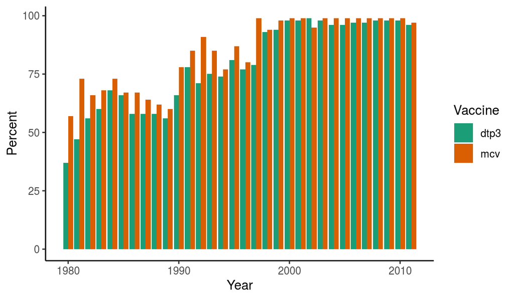

```r
# Code chunk to plot the data
numeric_vaccine %>%
  filter(country == "Brazil") %>%
  #selected Brazil
  ggplot(aes(x = year, y= percent, fill = vaccine)) +
  geom_col(position = "dodge") +
  #wanted the columns next to eachother
  labs(x = "Year", y = "Percent", fill = "Vaccine") +
  scale_fill_brewer(palette= "Dark2")
```

It is evident that in this figure, it shows that in the country Brazil, from 1980 to 2010 roughly, the percent of vaccinations definitely increased. It increased significantly around 1990.

#### Question 4

```r
# Code chunk to read in and examine the data with head()
read_csv(paste0(params$data_path, "seals.csv")) -> seals
seals
```

```
## # A tibble: 20 x 3
##     seal feeding oxygen_use
##    <dbl> <chr>        <dbl>
##  1     1 No            42.2
##  2     1 Yes           71
##  3     2 No            51.7
##  4     2 Yes           77.3
##  5     3 No            82.8
##  6     3 Yes           78.6
##  7     4 No            66.5
##  8     4 Yes           96.1
##  9     5 No            81.9
## 10     5 Yes          107.
## 11     6 No           110.
## 12     6 Yes          103.
## 13     7 No            81.3
## 14     7 Yes          121.
## 15     8 No            81.3
## 16     8 Yes          126.
## 17     9 No            96
## 18     9 Yes          128.
## 19    10 No           104.
## 20    10 Yes          143.
```

```r
head(seals)
```

```
## # A tibble: 6 x 3
##    seal feeding oxygen_use
##   <dbl> <chr>        <dbl>
## 1     1 No            42.2
## 2     1 Yes           71
## 3     2 No            51.7
## 4     2 Yes           77.3
## 5     3 No            82.8
## 6     3 Yes           78.6
```

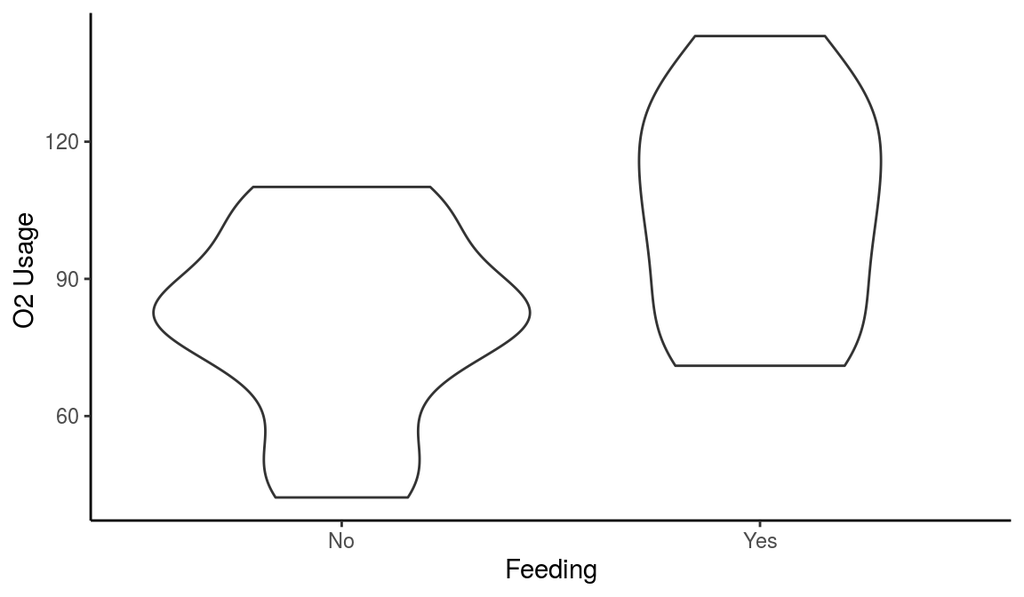

```r
# Code chunk for distributions (violin, sina, etc.)
# If sina make sure to load `ggforce()` in SETUP CHUNK!

seals %>%
  ggplot(aes(x = feeding, y = oxygen_use)) +
  geom_violin() +
  #violin plot shows distribution
  labs(x = "Feeding", y = "O2 Usage ")
```

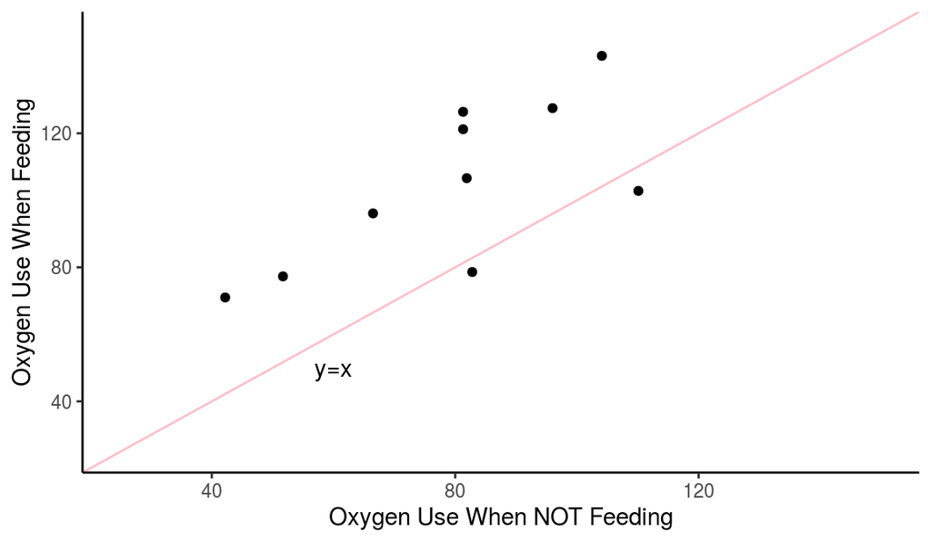

```r
# Code chunk for data un-tidying and scatterplot

seals %>%
  pivot_wider(names_from = "feeding", values_from = "oxygen_use") -> seals_feeding

seals_feeding %>%
  ggplot(aes(x = No, y = Yes)) +
  geom_point() +
  geom_abline(col = "pink") +
  #added y=x line
  labs( x = "Oxygen Use When NOT Feeding", y = "Oxygen Use When Feeding") +
  ylim(25,150) +
  #made y limit
  xlim(25,150) +
  #made x limit
  annotate("text", x = 60, y = 50, label = "y=x")
```

```r
  #added text annotation
```

Based on both figures, the oxygen use is increased WHEN feeding. You can tell this by the scatterplots positive increase. You can also tell this by the violin plot since the distribution is higher for oxygen use when feeding.

#### Question 5

```r
# Code chunk to read in and examine the data with head()
read_csv2(paste0(params$data_path, "planets.csv")) -> planets
```

```
## Using ',' as decimal and '.' as grouping mark. Use read_delim() for more control.
```

```r
planets
```

```
## # A tibble: 10 x 10
##    name  rotation_period orbital_period diameter climate gravity terrain
##    <chr>           <dbl>          <dbl>    <dbl> <chr>   <chr>   <chr>
##  1 Alde…              24            364    12500 temper… 1 stan… grassl…
##  2 Yavi…              24           4818    10200 temper… 1 stan… jungle…
##  3 Hoth               23            549     7200 frozen  1.1 st… tundra…
##  4 Dago…              23            341     8900 murky   N/A     swamp,…
##  5 Besp…              12           5110   118000 temper… 1.5 st… gas gi…
##  6 Endor              18            402     4900 temper… 0.85 s… forest…
##  7 Naboo              26            312    12120 temper… 1 stan… grassy…
##  8 Coru…              24            368    12240 temper… 1 stan… citysc…
##  9 Kami…              27            463    19720 temper… 1 stan… ocean
## 10 Geon…              30            256    11370 temper… 0.9 st… rock, …
## # … with 3 more variables: surface_water <chr>, population <chr>, edited <chr>
```

```r
head(planets)
```

```
## # A tibble: 6 x 10
##   name  rotation_period orbital_period diameter climate gravity terrain
##   <chr>           <dbl>          <dbl>    <dbl> <chr>   <chr>   <chr>
## 1 Alde…              24            364    12500 temper… 1 stan… grassl…
## 2 Yavi…              24           4818    10200 temper… 1 stan… jungle…
## 3 Hoth               23            549     7200 frozen  1.1 st… tundra…
## 4 Dago…              23            341     8900 murky   N/A     swamp,…
## 5 Besp…              12           5110   118000 temper… 1.5 st… gas gi…
## 6 Endor              18            402     4900 temper… 0.85 s… forest…
## # … with 3 more variables: surface_water <chr>, population <chr>, edited <chr>
```

```r
# Code chunk for tidying
# HINT: it's literally just piping data into separate_rows twice, one for the column given in the question, and for the second you need to figure out the column.
## DO NOT OVERCOMPLICATE THIS QUESTION.

planets %>%
  separate_rows(terrain) %>%
  #separated terrain because had multiple names
  separate_rows(climate) ->tidy_planets
  #separated climate because had multiple names
head(tidy_planets)
```

```
## # A tibble: 6 x 10
##   name  rotation_period orbital_period diameter climate gravity terrain
##   <chr>           <dbl>          <dbl>    <dbl> <chr>   <chr>   <chr>
## 1 Alde…              24            364    12500 temper… 1 stan… grassl…
## 2 Alde…              24            364    12500 temper… 1 stan… mounta…
## 3 Yavi…              24           4818    10200 temper… 1 stan… jungle
## 4 Yavi…              24           4818    10200 tropic… 1 stan… jungle
## 5 Yavi…              24           4818    10200 temper… 1 stan… rainfo…
## 6 Yavi…              24           4818    10200 tropic… 1 stan… rainfo…
## # … with 3 more variables: surface_water <chr>, population <chr>, edited <chr>
```

#### Question 6

```r
# Code chunk for allllll the wrangling and tidying
# should END UP as a single piped command - but build it up LINE AT A TIME!

tidy_planets %>%
  separate(edited, c("edited_date", "edited_time"), sep = "T") %>%
  #need to separate with "T" because that is where it separates the date and time
  mutate(ratio_period_rotation_orbital = rotation_period/orbital_period) %>%
  #dividing is way for ratio
  unite("name_pop", name, population, sep = "-") %>%
  #sep with a dash
  filter(terrain == "mountains") %>%
  #only want terrain
  arrange(desc(ratio_period_rotation_orbital)) -> mountain_planets
  #want it descending

mountain_planets
```

```
## # A tibble: 7 x 11
##   name_pop rotation_period orbital_period diameter climate gravity terrain
##   <chr>              <dbl>          <dbl>    <dbl> <chr>   <chr>   <chr>
## 1 Geonosi…              30            256    11370 temper… 0.9 st… mounta…
## 2 Geonosi…              30            256    11370 arid    0.9 st… mounta…
## 3 Naboo-4…              26            312    12120 temper… 1 stan… mounta…
## 4 Alderaa…              24            364    12500 temper… 1 stan… mounta…
## 5 Corusca…              24            368    12240 temper… 1 stan… mounta…
## 6 Endor-3…              18            402     4900 temper… 0.85 s… mounta…
## 7 Hoth-un…              23            549     7200 frozen  1.1 st… mounta…
## # … with 4 more variables: surface_water <chr>, edited_date <chr>,
## #   edited_time <chr>, ratio_period_rotation_orbital <dbl>
```

#### Question 7

```r
## defines each column as an array
tibble(
  color        = c("blue", "green", "turquoise"),
  male         = c(25, 36, 52),
  female       = c(28, 17, 33),
  species_abbr = c("sp1", "sp1", "sp1")
) -> frogs_sp1

## defines tibble in a format like the tibble would end up appearing
## spacing is helpful!
tribble(
  ~color, ~male, ~female, ~species_abbr,
  "orange", 13,   17,    "sp2",
  "red",    45,   36,    "sp2",
  "pink",  31,    25,    "sp2"
) -> frogs_sp2


## Like strategy one
tibble(
  species_name = c("Frogus firstus", "Frofus secondus"),
  species_abbr = c("sp1", "sp2")
) -> species_names

### ADD CODE HERE TO PRINT OUT THESE THREE DATASETS!!! YOU HAVE TO LOOK AT THEM TO USE THEM!!

frogs_sp1
```

```
## # A tibble: 3 x 4
##   color      male female species_abbr
##   <chr>     <dbl>  <dbl> <chr>
## 1 blue         25     28 sp1
## 2 green        36     17 sp1
## 3 turquoise    52     33 sp1
```

```r
frogs_sp2
```

```
## # A tibble: 3 x 4
##   color   male female species_abbr
##   <chr>  <dbl>  <dbl> <chr>
## 1 orange    13     17 sp2
## 2 red       45     36 sp2
## 3 pink      31     25 sp2
```

```r
species_names
```

```
## # A tibble: 2 x 2
##   species_name    species_abbr
##   <chr>           <chr>
## 1 Frogus firstus  sp1
## 2 Frofus secondus sp2
```

```r
# Code chunk to tidy and combine the three datasets

frogs_sp1 %>%
  bind_rows(frogs_sp2)%>%
  #the data is more or less the same so binded the rows
  left_join(species_names) -> tidy_frog
  #tried right and left join and didn't see much of a difference so just left join

tidy_frog #printed to make sure looked okay
```

```
## # A tibble: 6 x 5
##   color      male female species_abbr species_name
##   <chr>     <dbl>  <dbl> <chr>        <chr>
## 1 blue         25     28 sp1          Frogus firstus
## 2 green        36     17 sp1          Frogus firstus
## 3 turquoise    52     33 sp1          Frogus firstus
## 4 orange       13     17 sp2          Frofus secondus
## 5 red          45     36 sp2          Frofus secondus
## 6 pink         31     25 sp2          Frofus secondus
```

```r
tidy_frog %>%
  pivot_longer(male:female, names_to = "Frog_sex", values_to = "Frog_count") %>%
  select(-species_abbr) %>%
  #told to remove this column
  separate(species_name, c("Genus", "Species")) -> frog_tidy_tibble

frog_tidy_tibble
```

```
## # A tibble: 12 x 5
##    color     Genus  Species  Frog_sex Frog_count
##    <chr>     <chr>  <chr>    <chr>         <dbl>
##  1 blue      Frogus firstus  male             25
##  2 blue      Frogus firstus  female           28
##  3 green     Frogus firstus  male             36
##  4 green     Frogus firstus  female           17
##  5 turquoise Frogus firstus  male             52
##  6 turquoise Frogus firstus  female           33
##  7 orange    Frofus secondus male             13
##  8 orange    Frofus secondus female           17
##  9 red       Frofus secondus male             45
## 10 red       Frofus secondus female           36
## 11 pink      Frofus secondus male             31
## 12 pink      Frofus secondus female           25
```

```r
# Code chunk to for dplyr task 1
frog_tidy_tibble %>%
  filter(Species == "firstus") %>%
  #filtered by species : Frogus firstus
  filter(Frog_sex == "female") %>%
  filter(color %in% c("blue", "green"))
```

```
## # A tibble: 2 x 5
##   color Genus  Species Frog_sex Frog_count
##   <chr> <chr>  <chr>   <chr>         <dbl>
## 1 blue  Frogus firstus female           28
## 2 green Frogus firstus female           17
```

```r
#blue have more
```

```r
# Code chunk to for dplyr task 2
frog_tidy_tibble %>%
  filter(Frog_sex == "male") %>%
  #only wanted male
  group_by(Species) %>%
  #wanted to show species
  summarize(sum_males = sum(Frog_count))
```

```
## # A tibble: 2 x 2
##   Species  sum_males
##   <chr>        <dbl>
## 1 firstus        113
## 2 secondus        89
```

```r
  #wanted overall sum between species
```

```r
# Code chunk to for dplyr task 3
frog_tidy_tibble %>%
  filter(Species == "secondus") %>%
  select( -Genus) %>%
  select(- Species) %>%
  pivot_wider(names_from = "Frog_sex", values_from = "Frog_count") %>%
  mutate(ratio_frogs = male/female) %>%
  select(color, ratio_frogs) %>%
  arrange(desc(ratio_frogs))
```

```
## # A tibble: 3 x 2
##   color  ratio_frogs
##   <chr>        <dbl>
## 1 red          1.25
## 2 pink         1.24
## 3 orange       0.765
```

```r
#Red Frogus secondus have the highest male:female ratio!!
```

#### Question 8

```r
# Code chunk for kable()

frog_tidy_tibble %>%
  kable() %>%
  kable_styling(bootstrap_options = "hover", full_width = F, font_size = 10, position = "left") %>%
  #wanted to be able to hover over each line, towards left of page
  row_spec(1:2, color = "blue") %>%
  row_spec(3:4, color = "green") %>%
  row_spec(5:6, color = "turquoise") %>%
  row_spec(7:8, color = "orange") %>%
  row_spec(9:10, color = "red") %>%
  row_spec(11:12, color = "pink") -> kable_frog
  #made each color word the color it is

kable_frog
```

| color | Genus | Species | Frog_sex | Frog_count |
| --- | --- | --- | --- | --- |
| blue | Frogus | firstus | male | 25 |
| blue | Frogus | firstus | female | 28 |
| green | Frogus | firstus | male | 36 |
| green | Frogus | firstus | female | 17 |
| turquoise | Frogus | firstus | male | 52 |
| turquoise | Frogus | firstus | female | 33 |
| orange | Frofus | secondus | male | 13 |
| orange | Frofus | secondus | female | 17 |
| red | Frofus | secondus | male | 45 |
| red | Frofus | secondus | female | 36 |
| pink | Frofus | secondus | male | 31 |
| pink | Frofus | secondus | female | 25 |